# Project 2: Superstar Offensive Impact Variance & Playoff Winning Percentage

## Research Question

> **How does the variance of a superstar's offensive impact metric — points created minus empty possessions per possession, adjusted for usage and normalized per 75 possessions — relate to team playoff winning percentage?**

## Bottom Line

> Does consistency or volatility in superstar offensive performance matter more for winning in the playoffs? Can we quantify that relationship using machine learning?

## Methodology Overview

### Offensive Impact Score (OIS) per 75 Possessions

$$\text{Points Created} = \text{PTS} + 1.1 \times \text{AST}$$ $$\text{Empty Possessions} = (\text{FGA} - \text{FGM}) + 0.44 \times (\text{FTA} - \text{FTM}) + \text{TOV}$$ $$\text{OIS}_{\text{raw}} = \text{Points Created} - \text{Empty Possessions}$$ $$\text{Possessions Used} = \text{FGA} + 0.44 \times \text{FTA} + \text{TOV}$$ $$\text{OIS}_{/75} = \frac{\text{OIS}_{\text{raw}}}{\text{Possessions Used}} \times 75$$

### Variability Features (per player-season playoff log)

| Feature | Description |
| --- | --- |
| `mean_OIS_per75` | Average offensive impact |
| `std_OIS_per75` | Standard deviation — **core volatility** |
| `cv_OIS` | Coefficient of variation (std/mean) |
| `iqr_OIS` | Interquartile range — robust spread |
| `skew_OIS` | Skewness — explosive upside? |
| `kurt_OIS` | Kurtosis — outlier game frequency |
| `floor_OIS_p10` | 10th percentile — worst games |
| `ceiling_OIS_p90` | 90th percentile — best games |
| `ceiling_floor_ratio` | p90 / p10 — range quality |
| `pct_elite_games` | % of games above 75th percentile |

### Machine Learning Models

1. Linear Regression (baseline)
2. Ridge Regression (L2 regularization)
3. Lasso Regression (L1 / feature selection)
4. Random Forest (ensemble, non-linear)
5. Gradient Boosting (boosted ensemble)
6. SVR — Support Vector Regression (RBF kernel)

**Evaluation:** 5-fold cross-validated R² and RMSE. Permutation importance for interpretability.

```python
import pandas as pd
import numpy as np
import matplotlib.pyplot as plt
import matplotlib.gridspec as gridspec
import seaborn as sns
import warnings
warnings.filterwarnings("ignore")

from scipy import stats
from scipy.stats import pearsonr, spearmanr

from sklearn.linear_model import LinearRegression, Ridge, Lasso
from sklearn.ensemble import RandomForestRegressor, GradientBoostingRegressor
from sklearn.svm import SVR
from sklearn.pipeline import Pipeline
from sklearn.preprocessing import StandardScaler, RobustScaler
from sklearn.model_selection import (
    cross_val_score, KFold, GridSearchCV, cross_validate
)
from sklearn.metrics import mean_squared_error, r2_score
from sklearn.inspection import permutation_importance

plt.style.use("seaborn-v0_8-whitegrid")
sns.set_palette("husl")
RANDOM_STATE = 42
np.random.seed(RANDOM_STATE)

print("Imports complete.")
```

```
Imports complete.
```

## 1. Data Loading & Preprocessing

Using the same `playerstatistics.csv` dataset from Project 1, but now adding **all possession-related columns** (FGA, FTA, FGM, FTM, AST, TOV) required for the OIS metric.

```python
df = pd.read_csv("playerstatistics.csv", low_memory=False)

columns_to_keep = [
    "firstName", "lastName", "personId",
    "playerteamName", "gameDateTimeEst", "gameType", "gameId",
    "win",
    "points", "assists", "reboundsTotal",
    "numMinutes",
    "fieldGoalsMade", "fieldGoalsAttempted", "fieldGoalsPercentage",
    "threePointersMade", "threePointersAttempted", "threePointersPercentage",
    "freeThrowsMade", "freeThrowsAttempted", "freeThrowsPercentage",
    "turnovers",
    "blocks", "steals",
]

available = [c for c in columns_to_keep if c in df.columns]
df = df[available].copy()

df["playerName"] = (
    df["firstName"].astype(str).str.strip() + " " +
    df["lastName"].astype(str).str.strip()
)

# Numeric coercion
numeric_cols = [
    "points", "assists", "reboundsTotal", "numMinutes",
    "fieldGoalsMade", "fieldGoalsAttempted", "fieldGoalsPercentage",
    "threePointersMade", "threePointersAttempted", "threePointersPercentage",
    "freeThrowsMade", "freeThrowsAttempted", "freeThrowsPercentage",
    "turnovers", "blocks", "steals", "win",
]
for col in numeric_cols:
    if col in df.columns:
        df[col] = pd.to_numeric(df[col], errors="coerce")

df["game_date"] = pd.to_datetime(df["gameDateTimeEst"], errors="coerce")
df["season"] = df["game_date"].apply(
    lambda x: x.year if pd.notnull(x) and x.month >= 10 else (x.year - 1 if pd.notnull(x) else np.nan)
)
df["season_label"] = (
    df["season"].astype("Int64").astype(str) + "-" +
    (df["season"] + 1).astype("Int64").astype(str).str[-2:]
)

must_have = ["gameType", "playerteamName", "points", "win",
             "personId", "fieldGoalsMade", "fieldGoalsAttempted"]
df = df.dropna(subset=must_have)
df = df[df["numMinutes"] >= 10]

regular_season = df[df["gameType"] == "Regular Season"].copy()
playoffs       = df[df["gameType"] == "Playoffs"].copy()

print(f"Regular season game-logs: {len(regular_season):,}")
print(f"Playoff game-logs:        {len(playoffs):,}")
df.head(3)
```

```
Regular season game-logs: 1,067,967
Playoff game-logs:        68,078
```

|  | firstName | lastName | personId | playerteamName | gameDateTimeEst | gameType | gameId | win | points | assists | ... | freeThrowsMade | freeThrowsAttempted | freeThrowsPercentage | turnovers | blocks | steals | playerName | game_date | season | season_label |
| --- | --- | --- | --- | --- | --- | --- | --- | --- | --- | --- | --- | --- | --- | --- | --- | --- | --- | --- | --- | --- | --- |
| 0 | Kris | Dunn | 1627739.0 | Clippers | 2026-02-22 21:00:00 | Regular Season | 22500827 | 0.0 | 7.0 | 0.0 | ... | 3.0 | 4.0 | 0.75 | 1.0 | 0.0 | 2.0 | Kris Dunn | 2026-02-22 21:00:00 | 2025.0 | 2025-26 |
| 1 | Derrick | Jones Jr. | 1627884.0 | Clippers | 2026-02-22 21:00:00 | Regular Season | 22500827 | 0.0 | 6.0 | 3.0 | ... | 0.0 | 0.0 | 0.00 | 1.0 | 1.0 | 1.0 | Derrick Jones Jr. | 2026-02-22 21:00:00 | 2025.0 | 2025-26 |
| 2 | Jonathan | Isaac | 1628371.0 | Magic | 2026-02-22 21:00:00 | Regular Season | 22500827 | 1.0 | 5.0 | 1.0 | ... | 1.0 | 2.0 | 0.50 | 0.0 | 2.0 | 0.0 | Jonathan Isaac | 2026-02-22 21:00:00 | 2025.0 | 2025-26 |

3 rows × 28 columns

## 2. Superstar Identification

We define a **superstar season** as: ≥ 28 PPG and ≥ 50 games in a single regular season. (Slightly lower than Project 1's 30 PPG threshold to maximize playoff observations.)

```python
SCORING_THRESHOLD = 28
GAMES_THRESHOLD   = 50

season_avg = (
    regular_season
    .groupby(["personId", "playerName", "playerteamName", "season_label"])
    .agg(
        ppg=("points", "mean"),
        games_played=("gameId", "nunique")
    )
    .reset_index()
)

qualified_seasons = season_avg[
    (season_avg["ppg"] >= SCORING_THRESHOLD) &
    (season_avg["games_played"] >= GAMES_THRESHOLD)
].copy()

print(f"Qualified superstar seasons (≥{SCORING_THRESHOLD} PPG, ≥{GAMES_THRESHOLD} G): {len(qualified_seasons)}")
print(f"Unique superstars: {qualified_seasons['personId'].nunique()}")
print("\nSuperstar list:")
print(sorted(qualified_seasons["playerName"].unique()))
```

[output not shown]

## 3. Offensive Impact Score (OIS) per 75 Possessions

### Formula

$$\text{OIS}_{/75} = \frac{(\text{PTS} + 1.1 \cdot \text{AST}) - [(\text{FGA}-\text{FGM}) + 0.44(\text{FTA}-\text{FTM}) + \text{TOV}]}{\text{FGA} + 0.44 \cdot \text{FTA} + \text{TOV}} \times 75$$

- **Points Created** rewards scoring AND playmaking (assists estimated at 1.1 pts each)
- **Empty Possessions** penalizes missed shots, missed FTs (weighted by 0.44 possession cost), and turnovers
- **Per 75** normalizes across players with different usage rates and playing time

```python
def compute_ois(g):
    """Compute OIS per 75 possessions for a single game row."""
    pts  = g.get("points", 0) or 0
    ast  = g.get("assists", 0) or 0
    fgm  = g.get("fieldGoalsMade", 0) or 0
    fga  = g.get("fieldGoalsAttempted", 0) or 0
    ftm  = g.get("freeThrowsMade", 0) or 0
    fta  = g.get("freeThrowsAttempted", 0) or 0
    tov  = g.get("turnovers", 0) or 0

    points_created = pts + 1.1 * ast
    empty_poss     = (fga - fgm) + 0.44 * max(fta - ftm, 0) + tov
    poss_used      = fga + 0.44 * fta + tov

    if poss_used <= 0:
        return np.nan

    ois_raw    = points_created - empty_poss
    ois_per75  = (ois_raw / poss_used) * 75
    return ois_per75

regular_season = regular_season.copy()
playoffs       = playoffs.copy()

regular_season["OIS_per75"] = regular_season.apply(compute_ois, axis=1)
playoffs["OIS_per75"]       = playoffs.apply(compute_ois, axis=1)

print("OIS per-75 summary (ALL regular season players):")
print(regular_season["OIS_per75"].describe())
print()
print("OIS per-75 top game-logs:")
top_ois = regular_season.nlargest(10, "OIS_per75")[["playerName","game_date","points","assists","OIS_per75"]]
print(top_ois.to_string(index=False))
```

```
OIS per-75 summary (ALL regular season players):
count    1.065554e+06
mean     4.810973e+01
std      6.231656e+01
min     -7.500000e+01
25%      1.938154e+01
50%      4.575893e+01
75%      7.327089e+01
max      6.357955e+03
Name: OIS_per75, dtype: float64

OIS per-75 top game-logs:
     playerName           game_date  points  assists   OIS_per75
   Bill Russell 1962-02-16 19:00:00    23.0      3.0 6357.954545
  Calvin Murphy 1977-12-20 20:00:00    21.0      5.0 6221.590909
    Robert Reid 1979-11-10 20:00:00    21.0      3.0 5846.590909
      Ed Conlin 1957-12-25 19:00:00    21.0      3.0 5846.590909
      John Long 1979-11-10 20:00:00    17.0      6.0 5386.363636
    Robert Reid 1980-02-09 20:00:00    19.0      3.0 5335.227273
  Lenny Wilkens 1961-01-25 19:00:00    21.0      0.0 5284.090909
John Williamson 1979-11-07 20:00:00    17.0      5.0 5198.863636
     Bob Lanier 1970-10-28 19:00:00    19.0      0.0 4772.727273
     Bob Lanier 1977-01-27 19:00:00    36.0      2.0 4704.545455
```

## 4. Compute Variability Features from Playoff Game Logs

For each **(player, season)** pair, we compute 11 variability features from their game-by-game OIS_per75 distribution during the playoffs. This is the core innovation over Project 1.

```python
# Filter playoff games to superstars only
playoff_superstar = pd.merge(
    playoffs,
    qualified_seasons[["personId", "season_label"]],
    on=["personId", "season_label"],
    how="inner"
)

print(f"Playoff game-logs for superstars: {len(playoff_superstar):,}")
print(f"Player-seasons covered: {playoff_superstar.groupby(['personId','season_label']).ngroups}")

def pct_elite_games(series, q=0.75):
    """% of games where OIS exceeds player's own 75th percentile."""
    threshold = series.quantile(q)
    return (series > threshold).mean()

def build_variability_features(group):
    s = group["OIS_per75"].dropna()
    if len(s) < 4:
        return None

    mean_val  = s.mean()
    std_val   = s.std(ddof=1)
    iqr_val   = s.quantile(0.75) - s.quantile(0.25)
    cv_val    = std_val / abs(mean_val) if mean_val != 0 else np.nan
    skew_val  = s.skew()
    kurt_val  = s.kurtosis()
    p10       = s.quantile(0.10)
    p90       = s.quantile(0.90)
    cf_ratio  = p90 / abs(p10) if p10 != 0 else np.nan
    n_games   = len(s)
    pct_elite = pct_elite_games(s, q=0.75)

    return pd.Series({
        "mean_OIS_per75":      mean_val,
        "std_OIS_per75":       std_val,
        "cv_OIS":              cv_val,
        "iqr_OIS":             iqr_val,
        "skew_OIS":            skew_val,
        "kurt_OIS":            kurt_val,
        "floor_OIS_p10":       p10,
        "ceiling_OIS_p90":     p90,
        "ceiling_floor_ratio": cf_ratio,
        "playoff_games":       n_games,
        "pct_elite_games":     pct_elite,
    })

variability_features = (
    playoff_superstar
    .groupby(["personId", "playerName", "playerteamName", "season_label", "season"])
    .apply(build_variability_features)
    .dropna()
    .reset_index()
)

print(f"\nVariability feature rows (player-seasons): {len(variability_features)}")
variability_features[["playerName","season_label",
                       "mean_OIS_per75","std_OIS_per75","cv_OIS",
                       "skew_OIS","playoff_games"]].head(12)
```

```
Playoff game-logs for superstars: 1,274
Player-seasons covered: 116

Variability feature rows (player-seasons): 105
```

|  | playerName | season_label | mean_OIS_per75 | std_OIS_per75 | cv_OIS | skew_OIS | playoff_games |
| --- | --- | --- | --- | --- | --- | --- | --- |
| 0 | Patrick Ewing | 1989-90 | 50.133075 | 31.081522 | 0.619980 | 0.278259 | 10.0 |
| 1 | Karl Malone | 1989-90 | 33.567341 | 14.860751 | 0.442715 | -0.117721 | 5.0 |
| 2 | Karl Malone | 1990-91 | 42.401010 | 17.030147 | 0.401645 | 0.437832 | 9.0 |
| 3 | Karl Malone | 1991-92 | 54.226378 | 17.847155 | 0.329123 | -0.255595 | 16.0 |
| 4 | Shaquille O'Neal | 1997-98 | 53.814971 | 29.050815 | 0.539828 | 0.289915 | 13.0 |
| 5 | Shaquille O'Neal | 1999-00 | 46.946965 | 17.951950 | 0.382388 | -0.934211 | 23.0 |
| 6 | Shaquille O'Neal | 2000-01 | 43.989360 | 15.195089 | 0.345426 | -0.793857 | 16.0 |
| 7 | Shaquille O'Neal | 1994-95 | 50.454860 | 18.459826 | 0.365868 | -0.243602 | 21.0 |
| 8 | David Robinson | 1993-94 | 30.841832 | 36.383943 | 1.179695 | 0.153572 | 4.0 |
| 9 | Michael Jordan | 1984-85 | 58.288798 | 10.739762 | 0.184251 | 0.439838 | 4.0 |
| 10 | Michael Jordan | 1987-88 | 53.642727 | 16.338341 | 0.304577 | 0.237474 | 10.0 |
| 11 | Michael Jordan | 1988-89 | 61.165361 | 21.740882 | 0.355444 | -0.217809 | 17.0 |

## 5. Target Variable: Playoff Win %

We compute each team's win percentage within their actual playoff appearances in a given season — not the regular season win record.

```python
playoff_win_pct = (
    playoff_superstar
    .groupby(["playerteamName", "season"])["win"]
    .mean()
    .reset_index(name="playoff_win_pct")
)

model_df = pd.merge(
    variability_features,
    playoff_win_pct,
    on=["playerteamName", "season"],
    how="inner"
)

model_df = model_df.dropna(subset=["playoff_win_pct"])

print(f"Final modeling dataset: {len(model_df)} player-seasons")
print(f"\nPlayoff Win % distribution:")
print(model_df["playoff_win_pct"].describe())
print()
model_df[["playerName","season_label","playoff_win_pct",
          "mean_OIS_per75","std_OIS_per75","cv_OIS"]].head(12)
```

```
Final modeling dataset: 105 player-seasons

Playoff Win % distribution:
count    105.000000
mean       0.488502
std        0.175777
min        0.000000
25%        0.400000
50%        0.500000
75%        0.565217
max        0.937500
Name: playoff_win_pct, dtype: float64
```

|  | playerName | season_label | playoff_win_pct | mean_OIS_per75 | std_OIS_per75 | cv_OIS |
| --- | --- | --- | --- | --- | --- | --- |
| 0 | Patrick Ewing | 1989-90 | 0.400000 | 50.133075 | 31.081522 | 0.619980 |
| 1 | Karl Malone | 1989-90 | 0.400000 | 33.567341 | 14.860751 | 0.442715 |
| 2 | Karl Malone | 1990-91 | 0.444444 | 42.401010 | 17.030147 | 0.401645 |
| 3 | Karl Malone | 1991-92 | 0.562500 | 54.226378 | 17.847155 | 0.329123 |
| 4 | Shaquille O'Neal | 1997-98 | 0.538462 | 53.814971 | 29.050815 | 0.539828 |
| 5 | Shaquille O'Neal | 1999-00 | 0.652174 | 46.946965 | 17.951950 | 0.382388 |
| 6 | Shaquille O'Neal | 2000-01 | 0.937500 | 43.989360 | 15.195089 | 0.345426 |
| 7 | Shaquille O'Neal | 1994-95 | 0.523810 | 50.454860 | 18.459826 | 0.365868 |
| 8 | David Robinson | 1993-94 | 0.250000 | 30.841832 | 36.383943 | 1.179695 |
| 9 | Michael Jordan | 1984-85 | 0.250000 | 58.288798 | 10.739762 | 0.184251 |
| 10 | Michael Jordan | 1987-88 | 0.400000 | 53.642727 | 16.338341 | 0.304577 |
| 11 | Michael Jordan | 1988-89 | 0.529412 | 61.165361 | 21.740882 | 0.355444 |

## 6. Exploratory Data Analysis

### 6a. Correlation Heatmap & Volatility Scatter

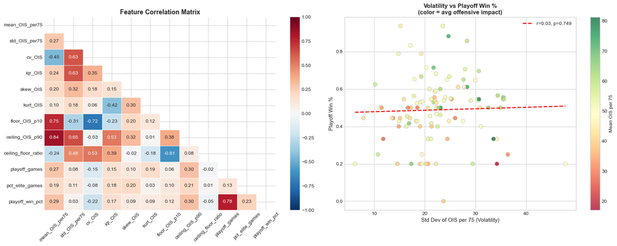

```python
FEATURE_COLS = [
    "mean_OIS_per75", "std_OIS_per75", "cv_OIS", "iqr_OIS",
    "skew_OIS", "kurt_OIS", "floor_OIS_p10", "ceiling_OIS_p90",
    "ceiling_floor_ratio", "playoff_games", "pct_elite_games",
]
TARGET = "playoff_win_pct"

fig, axes = plt.subplots(1, 2, figsize=(18, 7))

corr_mat = model_df[FEATURE_COLS + [TARGET]].corr()
mask = np.triu(np.ones_like(corr_mat, dtype=bool))
sns.heatmap(corr_mat, mask=mask, annot=True, fmt=".2f", cmap="RdBu_r",
            center=0, vmin=-1, vmax=1, ax=axes[0], linewidths=0.5)
axes[0].set_title("Feature Correlation Matrix", fontsize=13, fontweight="bold")
axes[0].tick_params(axis="x", rotation=45)

sc = axes[1].scatter(
    model_df["std_OIS_per75"],
    model_df["playoff_win_pct"],
    c=model_df["mean_OIS_per75"],
    cmap="RdYlGn", s=65, alpha=0.75, edgecolors="grey", linewidths=0.4
)
plt.colorbar(sc, ax=axes[1], label="Mean OIS per 75")
axes[1].set_xlabel("Std Dev of OIS per 75 (Volatility)", fontsize=11)
axes[1].set_ylabel("Playoff Win %", fontsize=11)
axes[1].set_title("Volatility vs Playoff Win %\n(color = avg offensive impact)",
                  fontsize=12, fontweight="bold")

m, b, r, p, se = stats.linregress(
    model_df["std_OIS_per75"], model_df["playoff_win_pct"])
x_range = np.linspace(model_df["std_OIS_per75"].min(),
                       model_df["std_OIS_per75"].max(), 100)
axes[1].plot(x_range, m*x_range + b, "r--", lw=2,
             label=f"r={r:.2f}, p={p:.3f}")
axes[1].legend(fontsize=10)
plt.tight_layout()
plt.show()
```

### 6b. Feature Distributions

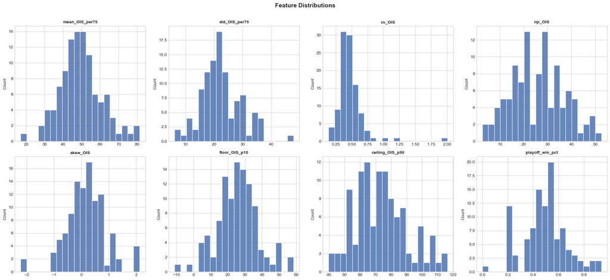

```python
fig, axes = plt.subplots(2, 4, figsize=(20, 9))
axes = axes.flatten()
plot_features = [
    "mean_OIS_per75", "std_OIS_per75", "cv_OIS", "iqr_OIS",
    "skew_OIS", "floor_OIS_p10", "ceiling_OIS_p90", "playoff_win_pct"
]
for i, col in enumerate(plot_features):
    axes[i].hist(model_df[col].dropna(), bins=20, color="#4C72B0",
                 edgecolor="white", alpha=0.85)
    axes[i].set_title(col, fontsize=10, fontweight="bold")
    axes[i].set_ylabel("Count")

plt.suptitle("Feature Distributions", fontsize=14, fontweight="bold", y=1.01)
plt.tight_layout()
plt.show()
```

### 6c. Pearson & Spearman Correlations with Target

```python
print(f"{'Feature':<25} {'Pearson r':>10} {'p-val':>10} {'Spearman ρ':>12} {'p-val':>10}")
print("-" * 72)
for col in FEATURE_COLS:
    sub = model_df[[col, TARGET]].dropna()
    pr, pp = pearsonr(sub[col], sub[TARGET])
    sr, sp = spearmanr(sub[col], sub[TARGET])
    sig_p = " *" if pp < 0.05 else "  "
    sig_s = " *" if sp < 0.05 else "  "
    print(f"{col:<25} {pr:>9.3f}{sig_p} {pp:>10.4f} {sr:>11.3f}{sig_s} {sp:>10.4f}")
print("\n* = p < 0.05")
```

```
Feature                    Pearson r      p-val   Spearman ρ      p-val
------------------------------------------------------------------------
mean_OIS_per75                0.291 *     0.0026       0.328 *     0.0006
std_OIS_per75                 0.032       0.7494       0.164       0.0945
cv_OIS                       -0.215 *     0.0275      -0.065       0.5114
iqr_OIS                       0.170       0.0831       0.206 *     0.0348
skew_OIS                      0.090       0.3611       0.082       0.4081
kurt_OIS                      0.092       0.3485       0.178       0.0700
floor_OIS_p10                 0.122       0.2165       0.123       0.2114
ceiling_OIS_p90               0.305 *     0.0016       0.381 *     0.0001
ceiling_floor_ratio          -0.055       0.5784       0.127       0.1975
playoff_games                 0.781 *     0.0000       0.848 *     0.0000
pct_elite_games               0.227 *     0.0201       0.213 *     0.0293

* = p < 0.05
```

## 7. High vs. Low Volatility Group Analysis

```
── High vs Low Volatility Group Stats (split at median CV):
                  avg_win_pct  std_win_pct   n
volatility_group
High Volatility      0.476221     0.179371  53
Low Volatility       0.501019     0.172874  52

Welch t-test: t=-0.721, p=0.4723
→ No statistically significant difference.
```

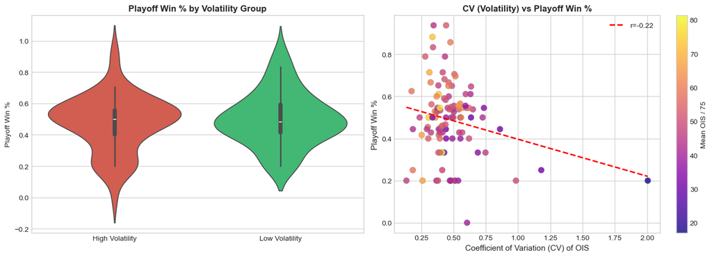

```python
median_cv = model_df["cv_OIS"].median()
model_df["volatility_group"] = np.where(
    model_df["cv_OIS"] >= median_cv, "High Volatility", "Low Volatility"
)

group_stats = (
    model_df.groupby("volatility_group")["playoff_win_pct"]
    .agg(["mean", "std", "count"])
    .rename(columns={"mean": "avg_win_pct", "std": "std_win_pct", "count": "n"})
)
print("── High vs Low Volatility Group Stats (split at median CV):")
print(group_stats)

hi = model_df[model_df["volatility_group"]=="High Volatility"]["playoff_win_pct"]
lo = model_df[model_df["volatility_group"]=="Low Volatility"]["playoff_win_pct"]
t_stat, t_pval = stats.ttest_ind(hi, lo, equal_var=False)
print(f"\nWelch t-test: t={t_stat:.3f}, p={t_pval:.4f}")
print("→ " + ("Significant difference." if t_pval < 0.05
               else "No statistically significant difference."))

fig, axes = plt.subplots(1, 2, figsize=(14, 5))

sns.violinplot(data=model_df, x="volatility_group", y="playoff_win_pct",
               palette=["#e74c3c", "#2ecc71"], inner="box", ax=axes[0])
axes[0].set_title("Playoff Win % by Volatility Group", fontsize=12, fontweight="bold")
axes[0].set_xlabel("")
axes[0].set_ylabel("Playoff Win %")

sc2 = axes[1].scatter(
    model_df["cv_OIS"], model_df["playoff_win_pct"],
    c=model_df["mean_OIS_per75"], cmap="plasma",
    s=70, alpha=0.8, edgecolors="grey", linewidths=0.3
)
plt.colorbar(sc2, ax=axes[1], label="Mean OIS / 75")
axes[1].set_xlabel("Coefficient of Variation (CV) of OIS", fontsize=11)
axes[1].set_ylabel("Playoff Win %", fontsize=11)
axes[1].set_title("CV (Volatility) vs Playoff Win %", fontsize=12, fontweight="bold")
m2, b2, r2v, p2, _ = stats.linregress(
    model_df["cv_OIS"].dropna(), model_df["playoff_win_pct"])
xr2 = np.linspace(model_df["cv_OIS"].min(), model_df["cv_OIS"].max(), 100)
axes[1].plot(xr2, m2*xr2 + b2, "r--", lw=2, label=f"r={r2v:.2f}")
axes[1].legend()
plt.tight_layout()
plt.show()
```

## 8. Machine Learning Models

We train 6 regression models with 5-fold cross-validation.

```python
X = model_df[FEATURE_COLS].copy()
y = model_df[TARGET].copy()

valid_mask = X.notna().all(axis=1) & y.notna()
X = X[valid_mask].reset_index(drop=True)
y = y[valid_mask].reset_index(drop=True)

print(f"ML Dataset: {len(X)} samples, {len(FEATURE_COLS)} features")

kf = KFold(n_splits=5, shuffle=True, random_state=RANDOM_STATE)

def evaluate_model(name, pipeline, X, y, cv):
    scores = cross_validate(
        pipeline, X, y, cv=cv,
        scoring=["r2", "neg_root_mean_squared_error"],
        return_train_score=True
    )
    return {
        "Model":       name,
        "CV R²":       round(scores["test_r2"].mean(), 4),
        "CV RMSE":     round(-scores["test_neg_root_mean_squared_error"].mean(), 4),
        "Train R²":    round(scores["train_r2"].mean(), 4),
        "Overfit Gap": round(scores["train_r2"].mean() - scores["test_r2"].mean(), 4),
    }

models = {
    "Linear Regression":  Pipeline([("scaler", StandardScaler()),
                                     ("model", LinearRegression())]),
    "Ridge (α=1)":        Pipeline([("scaler", StandardScaler()),
                                     ("model", Ridge(alpha=1.0))]),
    "Lasso (α=0.01)":     Pipeline([("scaler", StandardScaler()),
                                     ("model", Lasso(alpha=0.01, max_iter=5000))]),
    "Random Forest":      Pipeline([("scaler", RobustScaler()),
                                     ("model", RandomForestRegressor(
                                         n_estimators=300, max_depth=4,
                                         min_samples_leaf=3, random_state=RANDOM_STATE))]),
    "Gradient Boosting":  Pipeline([("scaler", RobustScaler()),
                                     ("model", GradientBoostingRegressor(
                                         n_estimators=200, learning_rate=0.05,
                                         max_depth=3, subsample=0.8,
                                         random_state=RANDOM_STATE))]),
    "SVR (RBF)":          Pipeline([("scaler", StandardScaler()),
                                     ("model", SVR(kernel="rbf", C=1.0, epsilon=0.05))]),
}

results = []
print(f"{'Model':<25} {'CV R²':>8} {'CV RMSE':>9} {'Train R²':>10} {'Overfit':>9}")
print("-" * 65)
for name, pipe in models.items():
    res = evaluate_model(name, pipe, X, y, kf)
    results.append(res)
    print(f"  {res['Model']:<23} {res['CV R²']:>8.4f} {res['CV RMSE']:>9.4f} "
          f"{res['Train R²']:>10.4f} {res['Overfit Gap']:>9.4f}")

results_df = pd.DataFrame(results).sort_values("CV R²", ascending=False)
print("\n── Model Leaderboard:")
results_df
```

```
ML Dataset: 105 samples, 11 features
Model                        CV R²   CV RMSE   Train R²   Overfit
-----------------------------------------------------------------
  Linear Regression         0.4552    0.1184     0.6604    0.2052
  Ridge (α=1)               0.4929    0.1159     0.6591    0.1663
  Lasso (α=0.01)            0.5686    0.1109     0.6325    0.0639
  Random Forest             0.6522    0.0991     0.8707    0.2184
  Gradient Boosting         0.5556    0.1091     0.9972    0.4416
  SVR (RBF)                 0.4211    0.1243     0.8565    0.4353

── Model Leaderboard:
```

|  | Model | CV R² | CV RMSE | Train R² | Overfit Gap |
| --- | --- | --- | --- | --- | --- |
| 3 | Random Forest | 0.6522 | 0.0991 | 0.8707 | 0.2184 |
| 2 | Lasso (α=0.01) | 0.5686 | 0.1109 | 0.6325 | 0.0639 |
| 4 | Gradient Boosting | 0.5556 | 0.1091 | 0.9972 | 0.4416 |
| 1 | Ridge (α=1) | 0.4929 | 0.1159 | 0.6591 | 0.1663 |
| 0 | Linear Regression | 0.4552 | 0.1184 | 0.6604 | 0.2052 |
| 5 | SVR (RBF) | 0.4211 | 0.1243 | 0.8565 | 0.4353 |

## 9. Hyperparameter Tuning — Random Forest & Gradient Boosting

```python
rf_grid = {"model__n_estimators":     [200, 400],
           "model__max_depth":        [3, 5, None],
           "model__min_samples_leaf": [2, 4]}

rf_pipe = Pipeline([("scaler", RobustScaler()),
                    ("model", RandomForestRegressor(random_state=RANDOM_STATE))])
rf_search = GridSearchCV(rf_pipe, rf_grid, cv=kf,
                         scoring="r2", n_jobs=-1, verbose=0)
rf_search.fit(X, y)
print(f"RF best params:  {rf_search.best_params_}")
print(f"RF best CV R²:   {rf_search.best_score_:.4f}")

gb_grid = {"model__n_estimators":  [150, 300],
           "model__learning_rate": [0.03, 0.05, 0.1],
           "model__max_depth":     [2, 3, 4]}

gb_pipe = Pipeline([("scaler", RobustScaler()),
                    ("model", GradientBoostingRegressor(
                        subsample=0.8, random_state=RANDOM_STATE))])
gb_search = GridSearchCV(gb_pipe, gb_grid, cv=kf,
                         scoring="r2", n_jobs=-1, verbose=0)
gb_search.fit(X, y)
print(f"\nGB best params:  {gb_search.best_params_}")
print(f"GB best CV R²:   {gb_search.best_score_:.4f}")
```

```
RF best params:  {'model__max_depth': 3, 'model__min_samples_leaf': 4, 'model__n_estimators': 400}
RF best CV R²:   0.6803

GB best params:  {'model__learning_rate': 0.03, 'model__max_depth': 2, 'model__n_estimators': 150}
GB best CV R²:   0.6039
```

## 10. Feature Importance — Permutation Method

Permutation importance is **model-agnostic** and directly measures how much each feature's random shuffling hurts predictive accuracy. This avoids the bias in tree-native importance metrics.

```
── Permutation Feature Importance (Random Forest):
            Feature  Importance      Std
      playoff_games    1.504061 0.116863
            iqr_OIS    0.018592 0.006456
             cv_OIS    0.017560 0.006252
ceiling_floor_ratio    0.013207 0.005786
      std_OIS_per75    0.005956 0.002205
    pct_elite_games    0.005729 0.001920
           kurt_OIS    0.005582 0.002048
    ceiling_OIS_p90    0.004860 0.002327
           skew_OIS    0.004571 0.001895
     mean_OIS_per75    0.004301 0.001008
      floor_OIS_p10    0.002829 0.001538
```

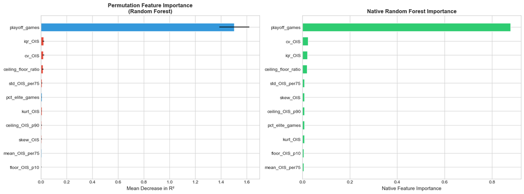

```python
best_model = (rf_search if rf_search.best_score_ >= gb_search.best_score_
              else gb_search)
best_name  = "Random Forest" if best_model is rf_search else "Gradient Boosting"
best_model.fit(X, y)

perm_imp = permutation_importance(
    best_model, X, y, n_repeats=30,
    random_state=RANDOM_STATE, scoring="r2"
)
perm_df = pd.DataFrame({
    "Feature":    FEATURE_COLS,
    "Importance": perm_imp.importances_mean,
    "Std":        perm_imp.importances_std,
}).sort_values("Importance", ascending=False)

print(f"── Permutation Feature Importance ({best_name}):")
print(perm_df.to_string(index=False))

fig, axes = plt.subplots(1, 2, figsize=(16, 6))

colors = ["#e74c3c" if any(k in f for k in ["std","cv","iqr","skew","kurt","ceil","ratio"])
          else "#3498db" for f in perm_df["Feature"]]
axes[0].barh(perm_df["Feature"], perm_df["Importance"],
             xerr=perm_df["Std"], color=colors, edgecolor="white", height=0.6)
axes[0].axvline(0, color="black", lw=0.8)
axes[0].set_xlabel("Mean Decrease in R²", fontsize=11)
axes[0].set_title(f"Permutation Feature Importance\n({best_name})",
                  fontsize=12, fontweight="bold")
axes[0].invert_yaxis()

# Native tree importance
tree_model = best_model.best_estimator_.named_steps["model"]


native_df = pd.DataFrame({
    "Feature":    FEATURE_COLS,
    "Importance": tree_model.feature_importances_,
}).sort_values("Importance", ascending=False)

axes[1].barh(native_df["Feature"], native_df["Importance"],
             color="#2ecc71", edgecolor="white", height=0.6)
axes[1].set_xlabel("Native Feature Importance", fontsize=11)
axes[1].set_title(f"Native {best_name} Importance", fontsize=12, fontweight="bold")
axes[1].invert_yaxis()

plt.tight_layout()
plt.show()
```

## 11. Bottom Line — Consistency vs. Volatility

```python
consistency_features = ["mean_OIS_per75", "floor_OIS_p10", "pct_elite_games"]
volatility_features  = ["std_OIS_per75",  "cv_OIS", "iqr_OIS", "skew_OIS", "kurt_OIS"]
ceiling_features     = ["ceiling_OIS_p90","ceiling_floor_ratio"]

pi_dict = dict(zip(perm_df["Feature"], perm_df["Importance"]))

score_consistency = sum(max(pi_dict.get(f, 0), 0) for f in consistency_features)
score_volatility  = sum(max(pi_dict.get(f, 0), 0) for f in volatility_features)
score_ceiling     = sum(max(pi_dict.get(f, 0), 0) for f in ceiling_features)
total             = score_consistency + score_volatility + score_ceiling + 1e-9

print("=" * 65)
print("BOTTOM LINE: Does Consistency or Volatility Win in Playoffs?")
print("=" * 65)
print(f"  Consistency signal  (mean, floor, elite%):  {score_consistency/total*100:.1f}%")
print(f"  Volatility signal   (std, CV, IQR, skew):   {score_volatility/total*100:.1f}%")
print(f"  Ceiling signal      (p90, CF-ratio):        {score_ceiling/total*100:.1f}%")

winner = max([("Consistency", score_consistency),
              ("Volatility",  score_volatility),
              ("Ceiling",     score_ceiling)],
             key=lambda x: x[1])[0]
print(f"\n  ➤ Dominant driver: {winner}")

r_cv, p_cv = pearsonr(model_df["cv_OIS"].dropna(),
                       model_df.loc[model_df["cv_OIS"].notna(), "playoff_win_pct"])
r_mn, p_mn = pearsonr(model_df["mean_OIS_per75"], model_df["playoff_win_pct"])
r_sd, p_sd = pearsonr(model_df["std_OIS_per75"].dropna(),
                       model_df.loc[model_df["std_OIS_per75"].notna(), "playoff_win_pct"])

print(f"\n  Pearson r (mean OIS vs playoff win%):  r={r_mn:.3f}, p={p_mn:.4f}")
print(f"  Pearson r (std OIS  vs playoff win%):  r={r_sd:.3f}, p={p_sd:.4f}")
print(f"  Pearson r (CV OIS   vs playoff win%):  r={r_cv:.3f}, p={p_cv:.4f}")

print(f"\n  Best model (tuned) CV R²: {max(rf_search.best_score_, gb_search.best_score_):.4f}")

if p_cv < 0.05:
    direction = "negatively" if r_cv < 0 else "positively"
    print(f"\n  → SIGNIFICANT: CV is {direction} correlated with playoff win %.")
    if r_cv < 0:
        print("    Interpretation: More CONSISTENT superstars → better playoff results.")
    else:
        print("    Interpretation: More VOLATILE superstars → better playoff results.")
else:
    print("\n  → No significant linear relationship (non-linear ML patterns may still exist).")
```

```
=================================================================
BOTTOM LINE: Does Consistency or Volatility Win in Playoffs?
=================================================================
  Consistency signal  (mean, floor, elite%):  15.5%
  Volatility signal   (std, CV, IQR, skew):   62.8%
  Ceiling signal      (p90, CF-ratio):        21.7%

  ➤ Dominant driver: Volatility

  Pearson r (mean OIS vs playoff win%):  r=0.291, p=0.0026
  Pearson r (std OIS  vs playoff win%):  r=0.032, p=0.7494
  Pearson r (CV OIS   vs playoff win%):  r=-0.215, p=0.0275

  Best model (tuned) CV R²: 0.6803

  → SIGNIFICANT: CV is negatively correlated with playoff win %.
    Interpretation: More CONSISTENT superstars → better playoff results.
```

## 12. Final Summary Visualization

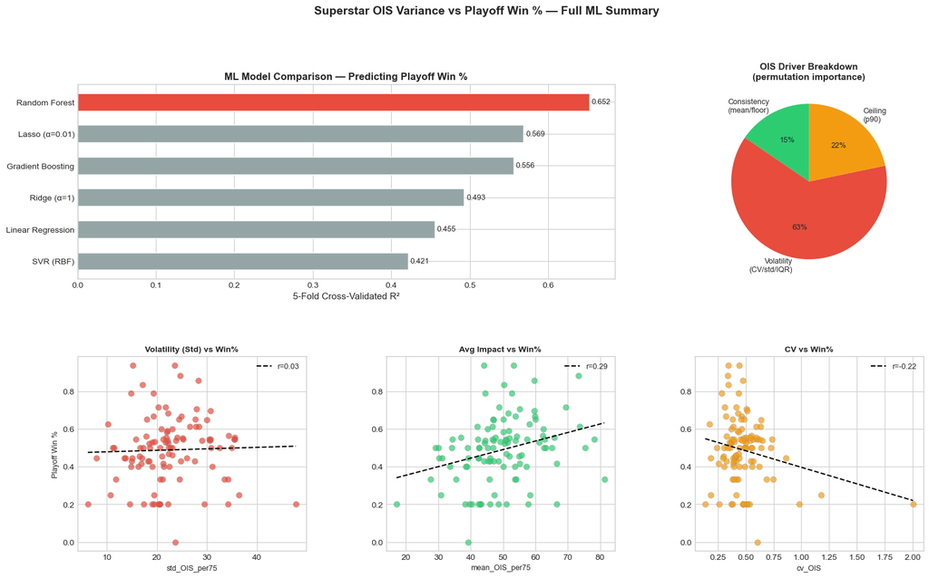

```python
fig = plt.figure(figsize=(18, 10))
gs  = gridspec.GridSpec(2, 3, figure=fig, hspace=0.4, wspace=0.35)

# (a) Model comparison
ax_models = fig.add_subplot(gs[0, :2])
bar_colors = ["#e74c3c" if i == 0 else "#95a5a6" for i in range(len(results_df))]
bars = ax_models.barh(results_df["Model"], results_df["CV R²"],
                       color=bar_colors, edgecolor="white", height=0.55)
ax_models.axvline(0, color="black", lw=0.8)
ax_models.set_xlabel("5-Fold Cross-Validated R²", fontsize=11)
ax_models.set_title("ML Model Comparison — Predicting Playoff Win %",
                     fontsize=12, fontweight="bold")
for bar, val in zip(bars, results_df["CV R²"]):
    ax_models.text(bar.get_width() + 0.003, bar.get_y() + bar.get_height()/2,
                   f"{val:.3f}", va="center", fontsize=9)
ax_models.invert_yaxis()

# (b) Driver pie
ax_pie = fig.add_subplot(gs[0, 2])
pie_vals  = [score_consistency, score_volatility, score_ceiling]
pie_lbls  = ["Consistency\n(mean/floor)", "Volatility\n(CV/std/IQR)", "Ceiling\n(p90)"]
pie_cols  = ["#2ecc71", "#e74c3c", "#f39c12"]
valid_pie = [(v, l, c) for v, l, c in zip(pie_vals, pie_lbls, pie_cols) if v > 0]
if valid_pie:
    vv, vl, vc = zip(*valid_pie)
    ax_pie.pie(vv, labels=vl, colors=vc, autopct="%1.0f%%",
               startangle=90, textprops={"fontsize": 9})
ax_pie.set_title("OIS Driver Breakdown\n(permutation importance)",
                  fontsize=11, fontweight="bold")

# (c-e) Scatter plots
for ax_idx, (col, color, label) in enumerate([
    ("std_OIS_per75",  "#e74c3c", f"r={r_sd:.2f}"),
    ("mean_OIS_per75", "#2ecc71", f"r={r_mn:.2f}"),
    ("cv_OIS",         "#f39c12", f"r={r_cv:.2f}"),
]):
    ax = fig.add_subplot(gs[1, ax_idx])
    sub = model_df[[col, "playoff_win_pct"]].dropna()
    ax.scatter(sub[col], sub["playoff_win_pct"],
               alpha=0.7, color=color, edgecolors="grey", linewidths=0.3, s=50)
    m_i, b_i, *_ = stats.linregress(sub[col], sub["playoff_win_pct"])
    xi = np.linspace(sub[col].min(), sub[col].max(), 100)
    ax.plot(xi, m_i*xi + b_i, "k--", lw=1.5, label=label)
    ax.legend(fontsize=9)
    ax.set_xlabel(col, fontsize=9)
    ax.set_ylabel("Playoff Win %" if ax_idx == 0 else "", fontsize=9)
    titles = ["Volatility (Std) vs Win%", "Avg Impact vs Win%", "CV vs Win%"]
    ax.set_title(titles[ax_idx], fontsize=10, fontweight="bold")

fig.suptitle("Superstar OIS Variance vs Playoff Win % — Full ML Summary",
             fontsize=14, fontweight="bold", y=1.01)
plt.show()
```

## 13. Lasso Coefficient Analysis — Feature Selection

Lasso regression drives unimportant features to zero, giving us an automatic feature selector.

```
Optimal alpha (LassoCV): 0.01109

Lasso Coefficients (standardized features):
            Feature  Coefficient
      playoff_games     0.122245
    pct_elite_games     0.011271
             cv_OIS    -0.006680
    ceiling_OIS_p90     0.002772
     mean_OIS_per75     0.000000
      std_OIS_per75    -0.000000
            iqr_OIS     0.000000
           skew_OIS     0.000000
           kurt_OIS    -0.000000
      floor_OIS_p10     0.000000
ceiling_floor_ratio    -0.000000
```

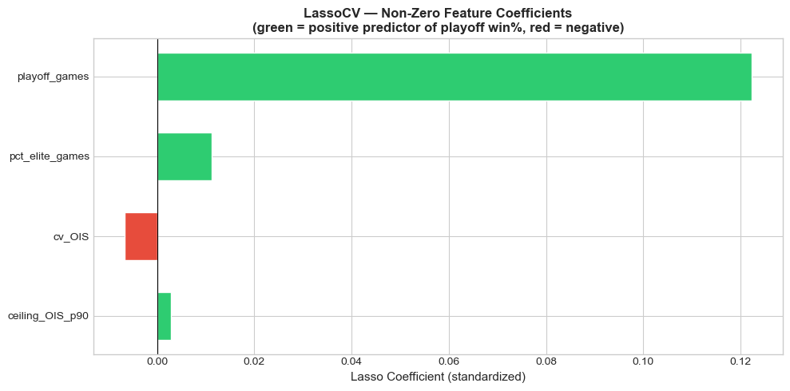

```python
from sklearn.linear_model import LassoCV

lasso_cv_pipe = Pipeline([
    ("scaler", StandardScaler()),
    ("model",  LassoCV(cv=kf, max_iter=10000, random_state=RANDOM_STATE))
])
lasso_cv_pipe.fit(X, y)

lasso_model = lasso_cv_pipe.named_steps["model"]
print(f"Optimal alpha (LassoCV): {lasso_model.alpha_:.5f}")

coef_df = pd.DataFrame({
    "Feature":     FEATURE_COLS,
    "Coefficient": lasso_model.coef_,
}).sort_values("Coefficient", key=abs, ascending=False)

print("\nLasso Coefficients (standardized features):")
print(coef_df.to_string(index=False))

# Plot
non_zero = coef_df[coef_df["Coefficient"] != 0]
colors_lasso = ["#e74c3c" if v < 0 else "#2ecc71" for v in non_zero["Coefficient"]]

fig, ax = plt.subplots(figsize=(10, 5))
ax.barh(non_zero["Feature"], non_zero["Coefficient"],
        color=colors_lasso, edgecolor="white", height=0.6)
ax.axvline(0, color="black", lw=0.8)
ax.set_xlabel("Lasso Coefficient (standardized)", fontsize=11)
ax.set_title("LassoCV — Non-Zero Feature Coefficients\n"
             "(green = positive predictor of playoff win%, red = negative)",
             fontsize=12, fontweight="bold")
ax.invert_yaxis()
plt.tight_layout()
plt.show()
```